# Risk Factor Analysis

## Outcome Variable

**Outcome Variable:** ever_wasted

## Predictor Variables

**Intervention Variable:** gagebrth

**Adjustment Set:**

- arm
- sex
- W_mage
- meducyrs
- feducyrs
- hhwealth_quart
- W_nrooms
- W_nchldlt5
- brthmon
- W_parity
- impfloor
- impsan
- safeh20
- delta_W_mage
- delta_meducyrs
- delta_feducyrs
- delta_hhwealth_quart
- delta_W_nrooms
- delta_W_nchldlt5
- delta_brthmon
- delta_W_parity
- delta_impfloor
- delta_impsan
- delta_safeh20

## Stratifying Variables

The analysis was stratified on these variable(s):

- agecat
- studyid
- country

## Data Summary

| agecat | studyid | country | gagebrth | ever_wasted | n_cell | n |
| --- | --- | --- | --- | --- | --- | --- |
| 0-24 months (no birth wast) | ki1000108-CMC-V-BCS-2002 | INDIA | Full or late term | 0 | 123 | 348 |
| 0-24 months (no birth wast) | ki1000108-CMC-V-BCS-2002 | INDIA | Full or late term | 1 | 90 | 348 |
| 0-24 months (no birth wast) | ki1000108-CMC-V-BCS-2002 | INDIA | Preterm | 0 | 25 | 348 |
| 0-24 months (no birth wast) | ki1000108-CMC-V-BCS-2002 | INDIA | Preterm | 1 | 27 | 348 |
| 0-24 months (no birth wast) | ki1000108-CMC-V-BCS-2002 | INDIA | Early term | 0 | 46 | 348 |
| 0-24 months (no birth wast) | ki1000108-CMC-V-BCS-2002 | INDIA | Early term | 1 | 37 | 348 |
| 0-24 months (no birth wast) | ki1000108-IRC | INDIA | Full or late term | 0 | 121 | 389 |
| 0-24 months (no birth wast) | ki1000108-IRC | INDIA | Full or late term | 1 | 128 | 389 |
| 0-24 months (no birth wast) | ki1000108-IRC | INDIA | Preterm | 0 | 16 | 389 |
| 0-24 months (no birth wast) | ki1000108-IRC | INDIA | Preterm | 1 | 26 | 389 |
| 0-24 months (no birth wast) | ki1000108-IRC | INDIA | Early term | 0 | 44 | 389 |
| 0-24 months (no birth wast) | ki1000108-IRC | INDIA | Early term | 1 | 54 | 389 |
| 0-24 months (no birth wast) | ki1000109-EE | PAKISTAN | Full or late term | 0 | 38 | 754 |
| 0-24 months (no birth wast) | ki1000109-EE | PAKISTAN | Full or late term | 1 | 12 | 754 |
| 0-24 months (no birth wast) | ki1000109-EE | PAKISTAN | Preterm | 0 | 264 | 754 |
| 0-24 months (no birth wast) | ki1000109-EE | PAKISTAN | Preterm | 1 | 222 | 754 |
| 0-24 months (no birth wast) | ki1000109-EE | PAKISTAN | Early term | 0 | 122 | 754 |
| 0-24 months (no birth wast) | ki1000109-EE | PAKISTAN | Early term | 1 | 96 | 754 |
| 0-24 months (no birth wast) | ki1000304b-SAS-CompFeed | INDIA | Full or late term | 0 | 19 | 1487 |
| 0-24 months (no birth wast) | ki1000304b-SAS-CompFeed | INDIA | Full or late term | 1 | 9 | 1487 |
| 0-24 months (no birth wast) | ki1000304b-SAS-CompFeed | INDIA | Preterm | 0 | 862 | 1487 |
| 0-24 months (no birth wast) | ki1000304b-SAS-CompFeed | INDIA | Preterm | 1 | 496 | 1487 |
| 0-24 months (no birth wast) | ki1000304b-SAS-CompFeed | INDIA | Early term | 0 | 66 | 1487 |
| 0-24 months (no birth wast) | ki1000304b-SAS-CompFeed | INDIA | Early term | 1 | 35 | 1487 |
| 0-24 months (no birth wast) | ki1017093c-NIH-Crypto | BANGLADESH | Full or late term | 0 | 152 | 754 |
| 0-24 months (no birth wast) | ki1017093c-NIH-Crypto | BANGLADESH | Full or late term | 1 | 16 | 754 |
| 0-24 months (no birth wast) | ki1017093c-NIH-Crypto | BANGLADESH | Preterm | 0 | 214 | 754 |
| 0-24 months (no birth wast) | ki1017093c-NIH-Crypto | BANGLADESH | Preterm | 1 | 47 | 754 |
| 0-24 months (no birth wast) | ki1017093c-NIH-Crypto | BANGLADESH | Early term | 0 | 280 | 754 |
| 0-24 months (no birth wast) | ki1017093c-NIH-Crypto | BANGLADESH | Early term | 1 | 45 | 754 |

[output cut: 186 more lines]

The following strata were considered:

- agecat: 0-24 months (no birth wast), studyid: ki1000108-CMC-V-BCS-2002, country: INDIA
- agecat: 0-24 months (no birth wast), studyid: ki1000108-IRC, country: INDIA
- agecat: 0-24 months (no birth wast), studyid: ki1000109-EE, country: PAKISTAN
- agecat: 0-24 months (no birth wast), studyid: ki1000304b-SAS-CompFeed, country: INDIA
- agecat: 0-24 months (no birth wast), studyid: ki1017093c-NIH-Crypto, country: BANGLADESH
- agecat: 0-24 months (no birth wast), studyid: ki1066203-TanzaniaChild2, country: TANZANIA, UNITED REPUBLIC OF
- agecat: 0-24 months (no birth wast), studyid: ki1101329-Keneba, country: GAMBIA
- agecat: 0-24 months (no birth wast), studyid: ki1119695-PROBIT, country: BELARUS
- agecat: 0-24 months (no birth wast), studyid: ki1135781-COHORTS, country: GUATEMALA
- agecat: 0-24 months (no birth wast), studyid: ki1135781-COHORTS, country: INDIA
- agecat: 0-24 months (no birth wast), studyid: ki1135781-COHORTS, country: PHILIPPINES
- agecat: 0-24 months (no birth wast), studyid: kiGH5241-JiVitA-3, country: BANGLADESH
- agecat: 0-6 months (no birth wast), studyid: ki1000108-CMC-V-BCS-2002, country: INDIA
- agecat: 0-6 months (no birth wast), studyid: ki1000108-IRC, country: INDIA
- agecat: 0-6 months (no birth wast), studyid: ki1000109-EE, country: PAKISTAN
- agecat: 0-6 months (no birth wast), studyid: ki1000304b-SAS-CompFeed, country: INDIA
- agecat: 0-6 months (no birth wast), studyid: ki1017093c-NIH-Crypto, country: BANGLADESH
- agecat: 0-6 months (no birth wast), studyid: ki1066203-TanzaniaChild2, country: TANZANIA, UNITED REPUBLIC OF
- agecat: 0-6 months (no birth wast), studyid: ki1101329-Keneba, country: GAMBIA
- agecat: 0-6 months (no birth wast), studyid: ki1119695-PROBIT, country: BELARUS
- agecat: 0-6 months (no birth wast), studyid: ki1135781-COHORTS, country: GUATEMALA
- agecat: 0-6 months (no birth wast), studyid: ki1135781-COHORTS, country: INDIA
- agecat: 0-6 months (no birth wast), studyid: ki1135781-COHORTS, country: PHILIPPINES
- agecat: 0-6 months (no birth wast), studyid: kiGH5241-JiVitA-3, country: BANGLADESH
- agecat: 6-24 months, studyid: ki1000108-CMC-V-BCS-2002, country: INDIA
- agecat: 6-24 months, studyid: ki1000108-IRC, country: INDIA
- agecat: 6-24 months, studyid: ki1000109-EE, country: PAKISTAN
- agecat: 6-24 months, studyid: ki1000304b-SAS-CompFeed, country: INDIA
- agecat: 6-24 months, studyid: ki1017093c-NIH-Crypto, country: BANGLADESH
- agecat: 6-24 months, studyid: ki1066203-TanzaniaChild2, country: TANZANIA, UNITED REPUBLIC OF
- agecat: 6-24 months, studyid: ki1101329-Keneba, country: GAMBIA
- agecat: 6-24 months, studyid: ki1119695-PROBIT, country: BELARUS
- agecat: 6-24 months, studyid: ki1135781-COHORTS, country: GUATEMALA
- agecat: 6-24 months, studyid: ki1135781-COHORTS, country: INDIA
- agecat: 6-24 months, studyid: ki1135781-COHORTS, country: PHILIPPINES
- agecat: 6-24 months, studyid: kiGH5241-JiVitA-3, country: BANGLADESH

### Dropped Strata

Some strata were dropped due to rare outcomes:

- agecat: 0-6 months (no birth wast), studyid: ki1000304b-SAS-CompFeed, country: INDIA
- agecat: 0-6 months (no birth wast), studyid: ki1135781-COHORTS, country: GUATEMALA

## Methods Detail

We’re interested in the causal parameters $E[Y_a]$ for all values of $a \in \mathcal{A}$. These parameters represent the mean outcome if, possibly contrary to fact, we intervened to set all units to have $A=a$. Under the randomization and positivity assumptions, these are identified by the statistical parameters $\psi_a=E_W[E_{Y|A,W}(Y|A=a,W)]$. In addition, we’re interested in the mean of $Y$, $E[Y]$ under no intervention (the observed mean). We will estimate these parameters by using SuperLearner to fit the relevant likelihood factors – $E_{Y|A,W}(Y|A=a,W)$ and $p(A=a|W)$, and then updating our likelihood fit using a joint TMLE.

For unadjusted analyses ($W=\{\}$), initial likelihoods were estimated using Lrnr_glm to estimate the simple $E(Y|A)$ and Lrnr_mean to estimate $p(A)$. For adjusted analyses, a small library containing Lrnr_glmnet, Lrnr_xgboost, and Lrnr_mean was used.

Having estimated these parameters, we will then use the delta method to estimate relative risks and attributable risks relative to a prespecified baseline level of $A$.

# Results Detail

## Results Plots

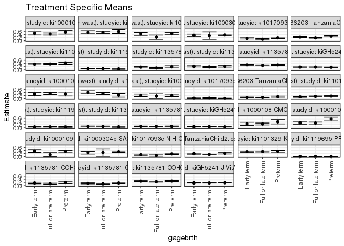

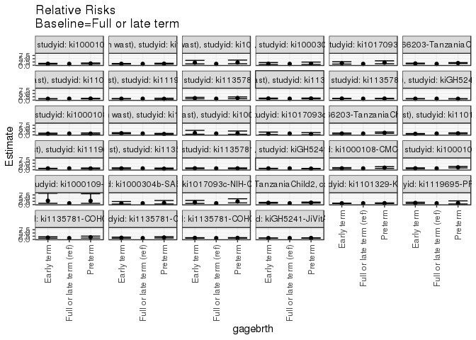

[figure not shown]

[figure not shown]

## Results Table

### Parameter: TSM

| agecat | studyid | country | intervention_level | baseline_level | estimate | ci_lower | ci_upper |
| --- | --- | --- | --- | --- | --- | --- | --- |
| 0-24 months (no birth wast) | ki1000108-CMC-V-BCS-2002 | INDIA | Full or late term | NA | 0.4249937 | 0.3597647 | 0.4902227 |
| 0-24 months (no birth wast) | ki1000108-CMC-V-BCS-2002 | INDIA | Preterm | NA | 0.5426207 | 0.4220974 | 0.6631440 |
| 0-24 months (no birth wast) | ki1000108-CMC-V-BCS-2002 | INDIA | Early term | NA | 0.4639857 | 0.3640414 | 0.5639300 |
| 0-24 months (no birth wast) | ki1000108-IRC | INDIA | Full or late term | NA | 0.5101244 | 0.4483063 | 0.5719425 |
| 0-24 months (no birth wast) | ki1000108-IRC | INDIA | Preterm | NA | 0.5844421 | 0.4488566 | 0.7200276 |
| 0-24 months (no birth wast) | ki1000108-IRC | INDIA | Early term | NA | 0.5348767 | 0.4389043 | 0.6308491 |
| 0-24 months (no birth wast) | ki1000109-EE | PAKISTAN | Full or late term | NA | 0.2225260 | 0.0853539 | 0.3596981 |
| 0-24 months (no birth wast) | ki1000109-EE | PAKISTAN | Preterm | NA | 0.4694789 | 0.4074977 | 0.5314602 |
| 0-24 months (no birth wast) | ki1000109-EE | PAKISTAN | Early term | NA | 0.4325284 | 0.3427654 | 0.5222913 |
| 0-24 months (no birth wast) | ki1000304b-SAS-CompFeed | INDIA | Full or late term | NA | 0.3214286 | 0.0856647 | 0.5571925 |
| 0-24 months (no birth wast) | ki1000304b-SAS-CompFeed | INDIA | Preterm | NA | 0.3652430 | 0.3139329 | 0.4165531 |
| 0-24 months (no birth wast) | ki1000304b-SAS-CompFeed | INDIA | Early term | NA | 0.3465347 | 0.2741080 | 0.4189613 |
| 0-24 months (no birth wast) | ki1017093c-NIH-Crypto | BANGLADESH | Full or late term | NA | 0.0897216 | 0.0469031 | 0.1325401 |
| 0-24 months (no birth wast) | ki1017093c-NIH-Crypto | BANGLADESH | Preterm | NA | 0.1759308 | 0.1300965 | 0.2217652 |
| 0-24 months (no birth wast) | ki1017093c-NIH-Crypto | BANGLADESH | Early term | NA | 0.1374960 | 0.1001027 | 0.1748892 |
| 0-24 months (no birth wast) | ki1066203-TanzaniaChild2 | TANZANIA, UNITED REPUBLIC OF | Full or late term | NA | 0.1738278 | 0.1540661 | 0.1935895 |
| 0-24 months (no birth wast) | ki1066203-TanzaniaChild2 | TANZANIA, UNITED REPUBLIC OF | Preterm | NA | 0.2800681 | 0.2359885 | 0.3241477 |
| 0-24 months (no birth wast) | ki1066203-TanzaniaChild2 | TANZANIA, UNITED REPUBLIC OF | Early term | NA | 0.2240935 | 0.1897751 | 0.2584119 |
| 0-24 months (no birth wast) | ki1101329-Keneba | GAMBIA | Full or late term | NA | 0.3691319 | 0.3369898 | 0.4012740 |
| 0-24 months (no birth wast) | ki1101329-Keneba | GAMBIA | Preterm | NA | 0.4064530 | 0.3475538 | 0.4653522 |
| 0-24 months (no birth wast) | ki1101329-Keneba | GAMBIA | Early term | NA | 0.3538589 | 0.3164123 | 0.3913055 |
| 0-24 months (no birth wast) | ki1119695-PROBIT | BELARUS | Full or late term | NA | 0.0712975 | 0.0583393 | 0.0842556 |
| 0-24 months (no birth wast) | ki1119695-PROBIT | BELARUS | Preterm | NA | 0.0657432 | 0.0364806 | 0.0950057 |
| 0-24 months (no birth wast) | ki1119695-PROBIT | BELARUS | Early term | NA | 0.0716915 | 0.0588337 | 0.0845494 |
| 0-24 months (no birth wast) | ki1135781-COHORTS | GUATEMALA | Full or late term | NA | 0.1207747 | 0.0907550 | 0.1507945 |
| 0-24 months (no birth wast) | ki1135781-COHORTS | GUATEMALA | Preterm | NA | 0.1907084 | 0.1251716 | 0.2562452 |
| 0-24 months (no birth wast) | ki1135781-COHORTS | GUATEMALA | Early term | NA | 0.1736482 | 0.1256214 | 0.2216750 |
| 0-24 months (no birth wast) | ki1135781-COHORTS | INDIA | Full or late term | NA | 0.1853134 | 0.1541714 | 0.2164554 |
| 0-24 months (no birth wast) | ki1135781-COHORTS | INDIA | Preterm | NA | 0.2201466 | 0.1763485 | 0.2639447 |
| 0-24 months (no birth wast) | ki1135781-COHORTS | INDIA | Early term | NA | 0.2182797 | 0.1817779 | 0.2547814 |

[output cut: 72 more lines]

### Parameter: E(Y)

| agecat | studyid | country | intervention_level | baseline_level | estimate | ci_lower | ci_upper |
| --- | --- | --- | --- | --- | --- | --- | --- |
| 0-24 months (no birth wast) | ki1000108-CMC-V-BCS-2002 | INDIA | NA | NA | 0.4425287 | 0.3902692 | 0.4947882 |
| 0-24 months (no birth wast) | ki1000108-IRC | INDIA | NA | NA | 0.5347044 | 0.4850733 | 0.5843354 |
| 0-24 months (no birth wast) | ki1000109-EE | PAKISTAN | NA | NA | 0.4376658 | 0.3875213 | 0.4878102 |
| 0-24 months (no birth wast) | ki1000304b-SAS-CompFeed | INDIA | NA | NA | 0.3631473 | 0.3130392 | 0.4132554 |
| 0-24 months (no birth wast) | ki1017093c-NIH-Crypto | BANGLADESH | NA | NA | 0.1432361 | 0.1182149 | 0.1682572 |
| 0-24 months (no birth wast) | ki1066203-TanzaniaChild2 | TANZANIA, UNITED REPUBLIC OF | NA | NA | 0.1975914 | 0.1811057 | 0.2140772 |
| 0-24 months (no birth wast) | ki1101329-Keneba | GAMBIA | NA | NA | 0.3725606 | 0.3495097 | 0.3956116 |
| 0-24 months (no birth wast) | ki1119695-PROBIT | BELARUS | NA | NA | 0.0716952 | 0.0597165 | 0.0836739 |
| 0-24 months (no birth wast) | ki1135781-COHORTS | GUATEMALA | NA | NA | 0.1470952 | 0.1226726 | 0.1715178 |
| 0-24 months (no birth wast) | ki1135781-COHORTS | INDIA | NA | NA | 0.2044610 | 0.1828992 | 0.2260227 |
| 0-24 months (no birth wast) | ki1135781-COHORTS | PHILIPPINES | NA | NA | 0.3030404 | 0.2865732 | 0.3195077 |
| 0-24 months (no birth wast) | kiGH5241-JiVitA-3 | BANGLADESH | NA | NA | 0.1756808 | 0.1694214 | 0.1819403 |
| 0-6 months (no birth wast) | ki1000108-CMC-V-BCS-2002 | INDIA | NA | NA | 0.3072289 | 0.2575285 | 0.3569293 |
| 0-6 months (no birth wast) | ki1000108-IRC | INDIA | NA | NA | 0.3477089 | 0.2991827 | 0.3962350 |
| 0-6 months (no birth wast) | ki1000109-EE | PAKISTAN | NA | NA | 0.1930295 | 0.1529228 | 0.2331362 |
| 0-6 months (no birth wast) | ki1017093c-NIH-Crypto | BANGLADESH | NA | NA | 0.0267023 | 0.0151493 | 0.0382553 |
| 0-6 months (no birth wast) | ki1066203-TanzaniaChild2 | TANZANIA, UNITED REPUBLIC OF | NA | NA | 0.0859445 | 0.0743193 | 0.0975697 |
| 0-6 months (no birth wast) | ki1101329-Keneba | GAMBIA | NA | NA | 0.1365979 | 0.1195068 | 0.1536891 |
| 0-6 months (no birth wast) | ki1119695-PROBIT | BELARUS | NA | NA | 0.0637570 | 0.0524446 | 0.0750694 |
| 0-6 months (no birth wast) | ki1135781-COHORTS | INDIA | NA | NA | 0.0864692 | 0.0708761 | 0.1020623 |
| 0-6 months (no birth wast) | ki1135781-COHORTS | PHILIPPINES | NA | NA | 0.0942127 | 0.0837084 | 0.1047169 |
| 0-6 months (no birth wast) | kiGH5241-JiVitA-3 | BANGLADESH | NA | NA | 0.0743146 | 0.0700205 | 0.0786087 |
| 6-24 months | ki1000108-CMC-V-BCS-2002 | INDIA | NA | NA | 0.2592593 | 0.2133485 | 0.3051700 |
| 6-24 months | ki1000108-IRC | INDIA | NA | NA | 0.3179487 | 0.2716722 | 0.3642252 |
| 6-24 months | ki1000109-EE | PAKISTAN | NA | NA | 0.3306667 | 0.2829875 | 0.3783458 |
| 6-24 months | ki1000304b-SAS-CompFeed | INDIA | NA | NA | 0.3060189 | 0.2640311 | 0.3480066 |
| 6-24 months | ki1017093c-NIH-Crypto | BANGLADESH | NA | NA | 0.1315068 | 0.1069744 | 0.1560393 |
| 6-24 months | ki1066203-TanzaniaChild2 | TANZANIA, UNITED REPUBLIC OF | NA | NA | 0.1591987 | 0.1427306 | 0.1756669 |
| 6-24 months | ki1101329-Keneba | GAMBIA | NA | NA | 0.3247706 | 0.3020649 | 0.3474764 |
| 6-24 months | ki1119695-PROBIT | BELARUS | NA | NA | 0.0100615 | 0.0072668 | 0.0128561 |
| 6-24 months | ki1135781-COHORTS | GUATEMALA | NA | NA | 0.1443433 | 0.1194882 | 0.1691984 |
| 6-24 months | ki1135781-COHORTS | INDIA | NA | NA | 0.1318764 | 0.1136647 | 0.1500881 |
| 6-24 months | ki1135781-COHORTS | PHILIPPINES | NA | NA | 0.2669537 | 0.2505274 | 0.2833801 |
| 6-24 months | kiGH5241-JiVitA-3 | BANGLADESH | NA | NA | 0.1699930 | 0.1628757 | 0.1771103 |

### Parameter: RR

| agecat | studyid | country | intervention_level | baseline_level | estimate | ci_lower | ci_upper |
| --- | --- | --- | --- | --- | --- | --- | --- |
| 0-24 months (no birth wast) | ki1000108-CMC-V-BCS-2002 | INDIA | Full or late term | Full or late term | 1.0000000 | 1.0000000 | 1.000000 |
| 0-24 months (no birth wast) | ki1000108-CMC-V-BCS-2002 | INDIA | Preterm | Full or late term | 1.2767735 | 0.9752853 | 1.671460 |
| 0-24 months (no birth wast) | ki1000108-CMC-V-BCS-2002 | INDIA | Early term | Full or late term | 1.0917472 | 0.8393359 | 1.420066 |
| 0-24 months (no birth wast) | ki1000108-IRC | INDIA | Full or late term | Full or late term | 1.0000000 | 1.0000000 | 1.000000 |
| 0-24 months (no birth wast) | ki1000108-IRC | INDIA | Preterm | Full or late term | 1.1456853 | 0.8817431 | 1.488636 |
| 0-24 months (no birth wast) | ki1000108-IRC | INDIA | Early term | Full or late term | 1.0485220 | 0.8443142 | 1.302120 |
| 0-24 months (no birth wast) | ki1000109-EE | PAKISTAN | Full or late term | Full or late term | 1.0000000 | 1.0000000 | 1.000000 |
| 0-24 months (no birth wast) | ki1000109-EE | PAKISTAN | Preterm | Full or late term | 2.1097713 | 1.1242425 | 3.959230 |
| 0-24 months (no birth wast) | ki1000109-EE | PAKISTAN | Early term | Full or late term | 1.9437207 | 1.0151995 | 3.721485 |
| 0-24 months (no birth wast) | ki1000304b-SAS-CompFeed | INDIA | Full or late term | Full or late term | 1.0000000 | 1.0000000 | 1.000000 |
| 0-24 months (no birth wast) | ki1000304b-SAS-CompFeed | INDIA | Preterm | Full or late term | 1.1363116 | 0.5359720 | 2.409088 |
| 0-24 months (no birth wast) | ki1000304b-SAS-CompFeed | INDIA | Early term | Full or late term | 1.0781078 | 0.5705854 | 2.037060 |
| 0-24 months (no birth wast) | ki1017093c-NIH-Crypto | BANGLADESH | Full or late term | Full or late term | 1.0000000 | 1.0000000 | 1.000000 |
| 0-24 months (no birth wast) | ki1017093c-NIH-Crypto | BANGLADESH | Preterm | Full or late term | 1.9608528 | 1.1378674 | 3.379079 |
| 0-24 months (no birth wast) | ki1017093c-NIH-Crypto | BANGLADESH | Early term | Full or late term | 1.5324733 | 0.8845669 | 2.654943 |
| 0-24 months (no birth wast) | ki1066203-TanzaniaChild2 | TANZANIA, UNITED REPUBLIC OF | Full or late term | Full or late term | 1.0000000 | 1.0000000 | 1.000000 |
| 0-24 months (no birth wast) | ki1066203-TanzaniaChild2 | TANZANIA, UNITED REPUBLIC OF | Preterm | Full or late term | 1.6111813 | 1.3276128 | 1.955318 |
| 0-24 months (no birth wast) | ki1066203-TanzaniaChild2 | TANZANIA, UNITED REPUBLIC OF | Early term | Full or late term | 1.2891695 | 1.0659147 | 1.559185 |
| 0-24 months (no birth wast) | ki1101329-Keneba | GAMBIA | Full or late term | Full or late term | 1.0000000 | 1.0000000 | 1.000000 |
| 0-24 months (no birth wast) | ki1101329-Keneba | GAMBIA | Preterm | Full or late term | 1.1011051 | 0.9305107 | 1.302975 |
| 0-24 months (no birth wast) | ki1101329-Keneba | GAMBIA | Early term | Full or late term | 0.9586246 | 0.8372500 | 1.097595 |
| 0-24 months (no birth wast) | ki1119695-PROBIT | BELARUS | Full or late term | Full or late term | 1.0000000 | 1.0000000 | 1.000000 |
| 0-24 months (no birth wast) | ki1119695-PROBIT | BELARUS | Preterm | Full or late term | 0.9220972 | 0.6008403 | 1.415124 |
| 0-24 months (no birth wast) | ki1119695-PROBIT | BELARUS | Early term | Full or late term | 1.0055273 | 0.8831062 | 1.144919 |
| 0-24 months (no birth wast) | ki1135781-COHORTS | GUATEMALA | Full or late term | Full or late term | 1.0000000 | 1.0000000 | 1.000000 |
| 0-24 months (no birth wast) | ki1135781-COHORTS | GUATEMALA | Preterm | Full or late term | 1.5790421 | 1.0340577 | 2.411252 |
| 0-24 months (no birth wast) | ki1135781-COHORTS | GUATEMALA | Early term | Full or late term | 1.4377859 | 0.9925553 | 2.082734 |
| 0-24 months (no birth wast) | ki1135781-COHORTS | INDIA | Full or late term | Full or late term | 1.0000000 | 1.0000000 | 1.000000 |
| 0-24 months (no birth wast) | ki1135781-COHORTS | INDIA | Preterm | Full or late term | 1.1879694 | 0.9170863 | 1.538864 |
| 0-24 months (no birth wast) | ki1135781-COHORTS | INDIA | Early term | Full or late term | 1.1778949 | 0.9307734 | 1.490628 |

[output cut: 72 more lines]

### Parameter: PAR

| agecat | studyid | country | intervention_level | baseline_level | estimate | ci_lower | ci_upper |
| --- | --- | --- | --- | --- | --- | --- | --- |
| 0-24 months (no birth wast) | ki1000108-CMC-V-BCS-2002 | INDIA | Full or late term | NA | 0.0175350 | -0.0231598 | 0.0582298 |
| 0-24 months (no birth wast) | ki1000108-IRC | INDIA | Full or late term | NA | 0.0245799 | -0.0127016 | 0.0618614 |
| 0-24 months (no birth wast) | ki1000109-EE | PAKISTAN | Full or late term | NA | 0.2151398 | 0.0798817 | 0.3503979 |
| 0-24 months (no birth wast) | ki1000304b-SAS-CompFeed | INDIA | Full or late term | NA | 0.0417187 | -0.1934900 | 0.2769274 |
| 0-24 months (no birth wast) | ki1017093c-NIH-Crypto | BANGLADESH | Full or late term | NA | 0.0535145 | 0.0130635 | 0.0939654 |
| 0-24 months (no birth wast) | ki1066203-TanzaniaChild2 | TANZANIA, UNITED REPUBLIC OF | Full or late term | NA | 0.0237636 | 0.0105817 | 0.0369455 |
| 0-24 months (no birth wast) | ki1101329-Keneba | GAMBIA | Full or late term | NA | 0.0034287 | -0.0191865 | 0.0260439 |
| 0-24 months (no birth wast) | ki1119695-PROBIT | BELARUS | Full or late term | NA | 0.0003977 | -0.0038960 | 0.0046915 |
| 0-24 months (no birth wast) | ki1135781-COHORTS | GUATEMALA | Full or late term | NA | 0.0263204 | 0.0041855 | 0.0484554 |
| 0-24 months (no birth wast) | ki1135781-COHORTS | INDIA | Full or late term | NA | 0.0191476 | -0.0046720 | 0.0429672 |
| 0-24 months (no birth wast) | ki1135781-COHORTS | PHILIPPINES | Full or late term | NA | 0.0202399 | -0.0002507 | 0.0407304 |
| 0-24 months (no birth wast) | kiGH5241-JiVitA-3 | BANGLADESH | Full or late term | NA | -0.0013206 | -0.0068729 | 0.0042316 |
| 0-6 months (no birth wast) | ki1000108-CMC-V-BCS-2002 | INDIA | Full or late term | NA | -0.0127711 | -0.0529146 | 0.0273724 |
| 0-6 months (no birth wast) | ki1000108-IRC | INDIA | Full or late term | NA | 0.0197839 | -0.0162355 | 0.0558033 |
| 0-6 months (no birth wast) | ki1000109-EE | PAKISTAN | Full or late term | NA | 0.0330295 | -0.1067560 | 0.1728150 |
| 0-6 months (no birth wast) | ki1017093c-NIH-Crypto | BANGLADESH | Full or late term | NA | -0.0090120 | -0.0328503 | 0.0148263 |
| 0-6 months (no birth wast) | ki1066203-TanzaniaChild2 | TANZANIA, UNITED REPUBLIC OF | Full or late term | NA | 0.0062614 | -0.0029905 | 0.0155133 |
| 0-6 months (no birth wast) | ki1101329-Keneba | GAMBIA | Full or late term | NA | -0.0067205 | -0.0239046 | 0.0104637 |
| 0-6 months (no birth wast) | ki1119695-PROBIT | BELARUS | Full or late term | NA | -0.0004602 | -0.0044722 | 0.0035518 |
| 0-6 months (no birth wast) | ki1135781-COHORTS | INDIA | Full or late term | NA | -0.0035013 | -0.0216061 | 0.0146035 |
| 0-6 months (no birth wast) | ki1135781-COHORTS | PHILIPPINES | Full or late term | NA | 0.0046396 | -0.0084369 | 0.0177161 |
| 0-6 months (no birth wast) | kiGH5241-JiVitA-3 | BANGLADESH | Full or late term | NA | -0.0027079 | -0.0064018 | 0.0009861 |
| 6-24 months | ki1000108-CMC-V-BCS-2002 | INDIA | Full or late term | NA | 0.0230456 | -0.0138795 | 0.0599707 |
| 6-24 months | ki1000108-IRC | INDIA | Full or late term | NA | 0.0251570 | -0.0089648 | 0.0592788 |
| 6-24 months | ki1000109-EE | PAKISTAN | Full or late term | NA | 0.2106667 | 0.0827068 | 0.3386265 |
| 6-24 months | ki1000304b-SAS-CompFeed | INDIA | Full or late term | NA | 0.0467596 | -0.1999217 | 0.2934409 |
| 6-24 months | ki1017093c-NIH-Crypto | BANGLADESH | Full or late term | NA | 0.0597894 | 0.0206162 | 0.0989625 |
| 6-24 months | ki1066203-TanzaniaChild2 | TANZANIA, UNITED REPUBLIC OF | Full or late term | NA | 0.0195717 | 0.0062239 | 0.0329195 |
| 6-24 months | ki1101329-Keneba | GAMBIA | Full or late term | NA | 0.0017732 | -0.0203091 | 0.0238554 |
| 6-24 months | ki1119695-PROBIT | BELARUS | Full or late term | NA | 0.0010981 | -0.0006579 | 0.0028542 |
| 6-24 months | ki1135781-COHORTS | GUATEMALA | Full or late term | NA | 0.0245711 | 0.0020561 | 0.0470861 |
| 6-24 months | ki1135781-COHORTS | INDIA | Full or late term | NA | 0.0220011 | 0.0021150 | 0.0418873 |
| 6-24 months | ki1135781-COHORTS | PHILIPPINES | Full or late term | NA | 0.0242358 | 0.0039118 | 0.0445598 |
| 6-24 months | kiGH5241-JiVitA-3 | BANGLADESH | Full or late term | NA | 0.0043283 | -0.0024157 | 0.0110724 |

### Parameter: PAF

| agecat | studyid | country | intervention_level | baseline_level | estimate | ci_lower | ci_upper |
| --- | --- | --- | --- | --- | --- | --- | --- |
| 0-24 months (no birth wast) | ki1000108-CMC-V-BCS-2002 | INDIA | Full or late term | NA | 0.0396246 | -0.0568526 | 0.1272946 |
| 0-24 months (no birth wast) | ki1000108-IRC | INDIA | Full or late term | NA | 0.0459692 | -0.0264665 | 0.1132933 |
| 0-24 months (no birth wast) | ki1000109-EE | PAKISTAN | Full or late term | NA | 0.4915618 | 0.0720659 | 0.7214141 |
| 0-24 months (no birth wast) | ki1000304b-SAS-CompFeed | INDIA | Full or late term | NA | 0.1148810 | -0.8371874 | 0.5735679 |
| 0-24 months (no birth wast) | ki1017093c-NIH-Crypto | BANGLADESH | Full or late term | NA | 0.3736103 | 0.0267211 | 0.5968637 |
| 0-24 months (no birth wast) | ki1066203-TanzaniaChild2 | TANZANIA, UNITED REPUBLIC OF | Full or late term | NA | 0.1202665 | 0.0515170 | 0.1840327 |
| 0-24 months (no birth wast) | ki1101329-Keneba | GAMBIA | Full or late term | NA | 0.0092032 | -0.0533942 | 0.0680807 |
| 0-24 months (no birth wast) | ki1119695-PROBIT | BELARUS | Full or late term | NA | 0.0055478 | -0.0562458 | 0.0637262 |
| 0-24 months (no birth wast) | ki1135781-COHORTS | GUATEMALA | Full or late term | NA | 0.1789348 | 0.0163884 | 0.3146197 |
| 0-24 months (no birth wast) | ki1135781-COHORTS | INDIA | Full or late term | NA | 0.0936492 | -0.0304617 | 0.2028120 |
| 0-24 months (no birth wast) | ki1135781-COHORTS | PHILIPPINES | Full or late term | NA | 0.0667894 | -0.0033244 | 0.1320036 |
| 0-24 months (no birth wast) | kiGH5241-JiVitA-3 | BANGLADESH | Full or late term | NA | -0.0075173 | -0.0396284 | 0.0236020 |
| 0-6 months (no birth wast) | ki1000108-CMC-V-BCS-2002 | INDIA | Full or late term | NA | -0.0415686 | -0.1807664 | 0.0812194 |
| 0-6 months (no birth wast) | ki1000108-IRC | INDIA | Full or late term | NA | 0.0568979 | -0.0525347 | 0.1549527 |
| 0-6 months (no birth wast) | ki1000109-EE | PAKISTAN | Full or late term | NA | 0.1711111 | -0.9844754 | 0.6537842 |
| 0-6 months (no birth wast) | ki1017093c-NIH-Crypto | BANGLADESH | Full or late term | NA | -0.3375000 | -1.5855791 | 0.3081216 |
| 0-6 months (no birth wast) | ki1066203-TanzaniaChild2 | TANZANIA, UNITED REPUBLIC OF | Full or late term | NA | 0.0728542 | -0.0408361 | 0.1741262 |
| 0-6 months (no birth wast) | ki1101329-Keneba | GAMBIA | Full or late term | NA | -0.0491991 | -0.1827604 | 0.0692800 |
| 0-6 months (no birth wast) | ki1119695-PROBIT | BELARUS | Full or late term | NA | -0.0072182 | -0.0719230 | 0.0535808 |
| 0-6 months (no birth wast) | ki1135781-COHORTS | INDIA | Full or late term | NA | -0.0404922 | -0.2721667 | 0.1489920 |
| 0-6 months (no birth wast) | ki1135781-COHORTS | PHILIPPINES | Full or late term | NA | 0.0492461 | -0.1000913 | 0.1783110 |
| 0-6 months (no birth wast) | kiGH5241-JiVitA-3 | BANGLADESH | Full or late term | NA | -0.0364379 | -0.0871642 | 0.0119215 |
| 6-24 months | ki1000108-CMC-V-BCS-2002 | INDIA | Full or late term | NA | 0.0888902 | -0.0649039 | 0.2204732 |
| 6-24 months | ki1000108-IRC | INDIA | Full or late term | NA | 0.0791228 | -0.0343270 | 0.1801289 |
| 6-24 months | ki1000109-EE | PAKISTAN | Full or late term | NA | 0.6370968 | -0.0338224 | 0.8726099 |
| 6-24 months | ki1000304b-SAS-CompFeed | INDIA | Full or late term | NA | 0.1527997 | -1.1757018 | 0.6701072 |
| 6-24 months | ki1017093c-NIH-Crypto | BANGLADESH | Full or late term | NA | 0.4546485 | 0.0765110 | 0.6779515 |
| 6-24 months | ki1066203-TanzaniaChild2 | TANZANIA, UNITED REPUBLIC OF | Full or late term | NA | 0.1229388 | 0.0358123 | 0.2021924 |
| 6-24 months | ki1101329-Keneba | GAMBIA | Full or late term | NA | 0.0054597 | -0.0649081 | 0.0711777 |
| 6-24 months | ki1119695-PROBIT | BELARUS | Full or late term | NA | 0.1091425 | -0.0756863 | 0.2622133 |
| 6-24 months | ki1135781-COHORTS | GUATEMALA | Full or late term | NA | 0.1702269 | 0.0010986 | 0.3107193 |
| 6-24 months | ki1135781-COHORTS | INDIA | Full or late term | NA | 0.1668315 | 0.0028454 | 0.3038495 |
| 6-24 months | ki1135781-COHORTS | PHILIPPINES | Full or late term | NA | 0.0907865 | 0.0114088 | 0.1637907 |
| 6-24 months | kiGH5241-JiVitA-3 | BANGLADESH | Full or late term | NA | 0.0254619 | -0.0150185 | 0.0643279 |